# Lab 8. Split Plot designs

Daniel Runcie. Modified from labs designed by Iago Hale, Dario Cantu and Jorge Dubcovsky

`r`r library(ggplot2) library(emmeans) library(lme4) library(lmerTest) library(pbkrtest) library(car)

## Split Plot with a RCBD as a main plot.

Split plots are used when a factorial design is necessary, but the two factors require different levels of randomization. The randomization takes two stages, first the main plot treatments among the main plots, and then the sub-plot treatments inside of each main plot. Because of this two-stage process, one looses sensitivity in detecting differences among main plot treatments (the first level of randomization) but gains sensitivity in detecting differences among subplot treatments (the second level), as well as the significance of the MainPlot*Subplot interaction.

In this study, four different fertilizers (main plots) were randomized within four blocks, and four different varieties of oats (subplots) were randomized within each of the sixteen main plots. The experiment was run as a split-plot because the fertilizers could only be applied to large sections of the field, while the oat varieties could be randomized to smaller plots within each section.

- Blocks: Four
- Main plots (Fertilizer): Four
- Subplots (Variety): Four (includes one control, SP1)

`r`r oat_data = read.csv(‘Oats.csv’) str(oat_data)

```
'data.frame':   64 obs. of  6 variables:
 $ Block     : Factor w/ 4 levels \Block_1\,\Block_2\,..: 1 1 1 1 1 1 1 1 1 1 ...
 $ MainPlot  : Factor w/ 16 levels \MP1\,\MP10\,\MP11\,..: 1 1 1 1 9 9 9 9 10 10 ...
 $ Fertilizer: Factor w/ 4 levels \F1\,\F2\,\F3\,..: 1 1 1 1 2 2 2 2 3 3 ...
 $ SubPlot   : int  1 2 3 4 1 2 3 4 1 2 ...
 $ Variety   : Factor w/ 4 levels \V1\,\V2\,\V3\,..: 2 1 3 4 1 2 3 4 4 3 ...
 $ Yield     : num  53.6 46.2 49.5 44.2 56.6 ...
```

### Model table

Here’s a diagram of the experiment. It can be helpful to draw this out for your experiment

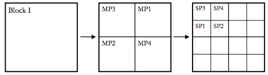

**Design**: Split plot with RCBD as a main plot

| Structure | Variable | Type | # levels | Experimental Unit |
| --- | --- | --- | --- | --- |
| Treatment | Fertilizer | Categorical | 4 | MainPlot or Fertilizer:Block |
|  | Variety | Categorical | 4 | SubPlot or Variety:Block |
|  | Fertilizer:Variety | Categorical | 16 | SubPlot or Fertilizer:Variety:Block |
| Design | Block | Categorical | 4 |  |
|  | MainPlot | Categorical | 16 |  |
|  | SubPlot | Categorical | 64 |  |
|  | Fertilizer:Block | Categorical | 16 |  |
|  | Variety:Block | Categorical | 16 |  |
|  | Fertilizer:Variety:Block | Categorical | 64 |  |
|  | Variety:MainPlot | Categorical | 64 |  |
|  | Fertilizer:Variety:MainPlot | Categorical | 64 |  |
| Response | Yield | Numeric | 64 |  |

There’s a lot going on in this table.

#### Variables

- I started with the two treatments and their interaction.
- I then added the 3 components of the Experimental Design: Block, MainPlot, SubPlot
- I then added terms for all possible combinations between Treatment and Design terms.
  - When one term is *Nested* in another term, there are no additional combinations.
    - Ex: MainPlot is nested in Fertilizer. Each MainPlot contains a single Fertilizer.
  - When two terms are *Crossed*, we add the combinations.
    - Ex: Block is crossed with: 1) Fertilizer (all Fertilizers in all Blocks), 2) Variety, and 3) the Fertilizer:Variety combinations.
    - Ex: MainPlot is crossed with Variety (all Varieties in each MainPlot)

#### Experimental Units

We need experimental units for the 3 treatment variables: *Fertilizer*, *Variety*, and *Fertilizer:Variety*

We have two choices of experimental units for each variable, depending on the goal of the experiment.

This experiment was run in a single field. We divided the field into 4 blocks, and ran the split-plot in each block.

- If the goal was to make recommendation for all possible blocks, we would use the *Block:Trt* terms as Experimental units
- If the goal is to use the blocks to control variation within *this field*, then we would use *MainPlot* or *SubPlot* as Experimental Units.

Here, extrapolating to new blocks doesn’t really make sense. There are no other blocks to extrapolate to. Sections in other fields may perform differently than these 4 sections in this field. So, there’s really no advantage to be gained by considering Blocks as Random.

Given this, we’ll analyze more as a Factorial with Blocks another factor. We can test for Block:Trt interactions, and then report main-effects if these interactions are not very large. We’ll have to remember that the Variety and Fertilizer effects we report, are **average** effects, averaged across plots in **this particular field**.

> So, given this, how do we decide on the Experimental Units?

*Fertilizer*: Fertilizers were random assigned to MainPlots (within each Block). Therefore, MainPlot is the Experimental Unit. *Variety*: Varieties were randomly assigned to SubPlots (within each MainPlot). Therefore, SubPlot is the Experimental Unit. *Fertilizer:Variety*: Specific combinations of Fertilizer and Variety were randomly assigned within SubPlots (within each MainPlot).

### Linear Model

Now that we have layed out our experiment, we can write our linear model.

First, we have to identify which terms to include in the model.

Rules:

1. Start with all terms.
2. Remove any terms that have the same # levels as the Response
3. When two terms are *aliased*, include only one (either will give the same answer). The value for the term is the combination.
4. Declare all terms that are Experimental Units of other terms *Random*.
5. Also declare any terms that are nested within *Random* terms to be *Random*.

#### Aliased terms

Terms that have the same # levels *MAY* be aliased.

Consider *MainPlot* and *Fertilizer:Block*. These both have 16 levels.

- Each Block has 4 MainPlots, each with a single Fertilizer.
- Each Fertilizer:Block combination is present in a single MainPlot.

These terms are *aliased*.

We can see that with `table`:

`r`r # make a new column in the data for Fertilizer:Block oat_data$Fert_Block = interaction(oat_data$Fertilizer,oat_data$Block,drop = TRUE) table(oat_data$Fert_Block,oat_data$MainPlot)

```
             MP1 MP10 MP11 MP12 MP13 MP14 MP15 MP16 MP2 MP3 MP4 MP5 MP6 MP7 MP8 MP9
  F1.Block_1   4    0    0    0    0    0    0    0   0   0   0   0   0   0   0   0
  F2.Block_1   0    0    0    0    0    0    0    0   4   0   0   0   0   0   0   0
  F3.Block_1   0    0    0    0    0    0    0    0   0   4   0   0   0   0   0   0
  F4.Block_1   0    0    0    0    0    0    0    0   0   0   4   0   0   0   0   0
  F1.Block_2   0    0    0    0    0    0    0    0   0   0   0   4   0   0   0   0
  F2.Block_2   0    0    0    0    0    0    0    0   0   0   0   0   4   0   0   0
  F3.Block_2   0    0    0    0    0    0    0    0   0   0   0   0   0   4   0   0
  F4.Block_2   0    0    0    0    0    0    0    0   0   0   0   0   0   0   4   0
  F1.Block_3   0    0    0    0    0    0    0    0   0   0   0   0   0   0   0   4
  F2.Block_3   0    4    0    0    0    0    0    0   0   0   0   0   0   0   0   0
  F3.Block_3   0    0    4    0    0    0    0    0   0   0   0   0   0   0   0   0
  F4.Block_3   0    0    0    4    0    0    0    0   0   0   0   0   0   0   0   0
  F1.Block_4   0    0    0    0    4    0    0    0   0   0   0   0   0   0   0   0
  F2.Block_4   0    0    0    0    0    4    0    0   0   0   0   0   0   0   0   0
  F3.Block_4   0    0    0    0    0    0    4    0   0   0   0   0   0   0   0   0
  F4.Block_4   0    0    0    0    0    0    0    4   0   0   0   0   0   0   0   0
```

In this matrix, columns are the 16 MainPlots, and rows are each of the combinations of Fertilizer and Block.

Each cell counts the number of observations of each combination. Each row/column only has a single non-zero entry. Thus they are *aliased*.

*Fertilizer:Variety* and *Variety:Block* also have 16 levels in our table. However, these are *Partially Crossed* with eachother and with *MainPlot* (ie, not all combinations are present, but > 1 are)

> Convince yourself of this! Make the tables.

Now, we can write our model. Split Plots always require `lmer` because they have multiple Experimental Units. *MainPlot* will ALWAYS be random!

`r`r oats_model <- lmer(Yield ~ Fertilizer + Variety + Fertilizer:Variety + # treatment terms Block + (1|MainPlot) + # Design terms. SubPlot not included because aliased with Yield Variety:Block # Fertilizer:Block is not included because we included MainPlot and they are aliased # Fertilizer:Variety:Block, Variety:MainPlot, Fertilizer:Variety:MainPlot - not included because aliased with Yield ,data = oat_data )

### Diagnostics

For the diagnostics of a Split-plot experiment, we have to do diagnostics on **all experimental units**. We have two different experimental units for the three treatments:

- *MainPlot* for Fertilizer
- *SubPlot* for Variety and Fertilizer:Variety

The *SubPlot* experimental units are aliased with the observations. Therefore we can access the estimates of these EU’s with the `resid()` function. We can make the qqplot and S/L plots like this:

`r`r par(mfrow=c(1,2)) ## qqplot qqPlot(resid(oats_model))

```
[1] 39 26
```

`r`r ## S/L plot fitted_values = fitted(oats_model) abs_sqrt_resids = sqrt(abs(resid(oats_model,scaled=T))) scatter.smooth(fitted_values,abs_sqrt_resids,span = 1,main = ‘Scale-Location’,ylab = expression(sqrt(abs(‘deviations’))),xlab = ‘Fitted values’)

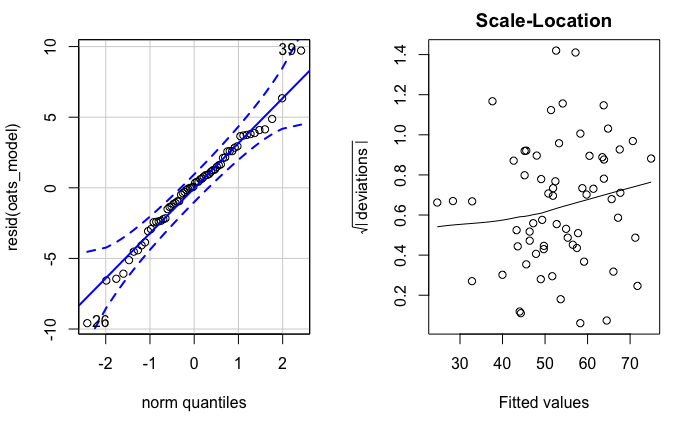

> These all look pretty good.

Now, for the *MainPlot* experimental units, we have to estimate their values like we do in normal `lmer()` models. Actually, the processes here is slightly more involved. To get the estimate values, we have to fit a reduced model with *no subplot* terms. We can get the estimates from this model:

`r`r # No-subplot-model: Same as oats_model, but only variables that are constant within each mainplot mainplot_model <- lmer(Yield ~ Fertilizer + # treatment terms Block + (1|MainPlot) # Design terms. SubPlot not included because aliased with Yield ,data = oat_data ) # Now, using this model, the code is similar to what you have seen before par(mfrow=c(1,2)) # # Step 1: Extract estimates of the experimental unit deviations eu_data = aggregate(Yield ~ Fertilizer + Block + MainPlot,oat_data,FUN = mean) # Again, include all terms in the mainplot_model # you’ll have to adapt this for other experiments with other Variables eu_data$deviation = ranef(mainplot_model)$MainPlot[eu_data$MainPlot,1] # The key above is to substitute `Plot` for the name of your random experimental unit term above in both places # emmeans(oats_model,specs = ‘MainPlot’,lmer.df = ‘K’) eu_data$fitted = predict(mainplot_model,newdata = eu_data,re.form = ~0) # This line you can use directly # # # Step 2: Make QQplot and `Scale-Location` plot: # op = par(mfrow=c(1,2)) # two plots side-by-side qqPlot(eu_data$deviation,main = ‘Plot (EU) Normal Q-Q’,pch=19) # new qqplot function

```
[1] 14 13
```

`r`r scatter.smooth(eu_data$fitted,sqrt(abs(eu_data$deviation)),span = 1,main = ‘Scale-Location’,ylab = expression(sqrt(abs(‘deviations’))),xlab = ‘Fitted values’)

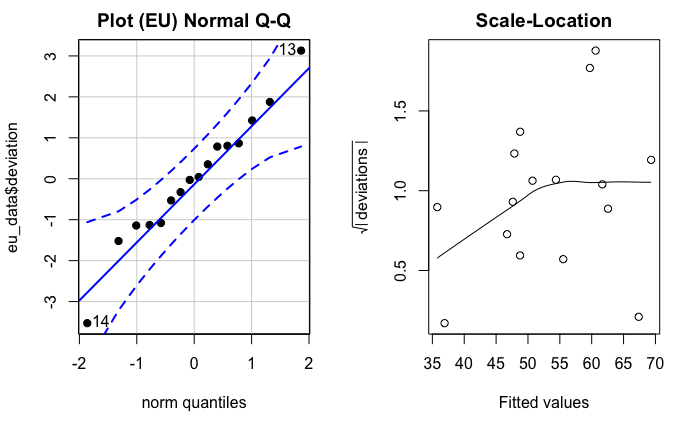

> all diagnostics look fine here too.

### Analysis

Our analysis of a SplitPlot is really just like for a factorial (it is just a factorial!)

ANOVA:

`r`r anova(oats_model,ddf=‘K’)

```
Type III Analysis of Variance Table with Kenward-Roger's method
                   Sum Sq Mean Sq NumDF DenDF F value    Pr(>F)
Fertilizer         962.55  320.85     3     9 13.8186 0.0010220 **
Variety            136.20   45.40     3    27  1.9553 0.1445378
Block              983.68  327.89     3     9 14.1219 0.0009445 ***
Fertilizer:Variety 586.47   65.16     9    27  2.8065 0.0182560 *
Variety:Block      348.45   38.72     9    27  1.6675 0.1462517
---
Signif. codes:  0 ‘***’ 0.001 ‘**’ 0.01 ‘*’ 0.05 ‘.’ 0.1 ‘ ’ 1
```

We analyze this like a 3-way factorial, except we are missing one of the 2-way interactions, and the 3-way interactions.

#### Questions

> Should you report main effects or specific effects for Fertilizer and Variety? What about Block:Trt? Can you report main effects for Variety? Fertilizer?

> Note: Fertilizer has 9 DenDF, but Variety has 27. Why? What will this do to our confidence intervals for each term?

### Means comparisons

Since we see evidence that the Fertilizer effects are dependent on the particular varieties, we should report simple effects of Fertilizer for each variety. The syntax is straightforward:

`r`r oats_means = emmeans(oats_model,specs = ‘Fertilizer’,by=‘Variety’,lmer.df = ‘K’) cld(oats_means,level = 0.05/4) # adjusted for 4 sets of comparisons (4 varieties)

```
Variety = V1:
 Fertilizer   emmean       SE    df lower.CL upper.CL .group
 F1         37.06228 2.940624 27.19 37.01578 37.10878  1
 F2         51.86228 2.940624 27.19 51.81578 51.90878   2
 F3         54.93728 2.940624 27.19 54.89078 54.98378   2
 F4         62.93728 2.940624 27.19 62.89078 62.98378   2

Variety = V2:
 Fertilizer   emmean       SE    df lower.CL upper.CL .group
 F1         50.75742 2.940624 27.19 50.71092 50.80392  1
 F3         51.50742 2.940624 27.19 51.46092 51.55392  1
 F2         55.50742 2.940624 27.19 55.46092 55.55392  12
 F4         63.55742 2.940624 27.19 63.51092 63.60392   2

Variety = V3:
 Fertilizer   emmean       SE    df lower.CL upper.CL .group
 F1         46.95998 2.940624 27.19 46.91348 47.00647  1
 F2         54.20998 2.940624 27.19 54.16348 54.25647  12
 F3         56.98498 2.940624 27.19 56.93848 57.03147  12
 F4         58.78498 2.940624 27.19 58.73848 58.83147   2

Variety = V4:
 Fertilizer   emmean       SE    df lower.CL upper.CL .group
 F1         37.38401 2.940624 27.19 37.33751 37.43050  1
 F2         54.38401 2.940624 27.19 54.33751 54.43050   2
 F3         56.13401 2.940624 27.19 56.08751 56.18050   2
 F4         61.33401 2.940624 27.19 61.28751 61.38050   2

Results are averaged over the levels of: Block
Degrees-of-freedom method: kenward-roger
Confidence level used: 0.0125
P value adjustment: tukey method for comparing a family of 4 estimates
significance level used: alpha = 0.05
```

Had we wanted main effects, we could get them as expected:

`r`r # Fertilizer effects oats_main_effects_fertilizer = emmeans(oats_model,specs = ‘Fertilizer’,lmer.df = ‘K’)

```
NOTE: Results may be misleading due to involvement in interactions
```

`r`r cld(oats_main_effects_fertilizer)

```
 Fertilizer   emmean       SE df lower.CL upper.CL .group
 F1         43.04092 2.072137  9 38.35342 47.72842  1
 F2         53.99092 2.072137  9 49.30342 58.67842   2
 F3         54.89092 2.072137  9 50.20342 59.57842   2
 F4         61.65342 2.072137  9 56.96592 66.34092   2

Results are averaged over the levels of: Variety, Block
Degrees-of-freedom method: kenward-roger
Confidence level used: 0.95
P value adjustment: tukey method for comparing a family of 4 estimates
significance level used: alpha = 0.05
```

`r`r # Variety effects oats_main_effects_variety = emmeans(oats_model,specs = ‘Variety’,lmer.df = ‘K’)

```
NOTE: Results may be misleading due to involvement in interactions
```

`r`r cld(oats_main_effects_variety)

```
 Variety   emmean       SE    df lower.CL upper.CL .group
 V1      51.69978 1.470312 27.19 48.68392 54.71564  1
 V4      52.30901 1.470312 27.19 49.29314 55.32487  1
 V3      54.23498 1.470312 27.19 51.21912 57.25084  1
 V2      55.33242 1.470312 27.19 52.31656 58.34828  1

Results are averaged over the levels of: Fertilizer, Block
Degrees-of-freedom method: kenward-roger
Confidence level used: 0.95
P value adjustment: tukey method for comparing a family of 4 estimates
significance level used: alpha = 0.05
```

> Note: the standard errors and df’s are different for the two types of treatments.

We could also make comparisons between all specific combinations of Fertilizer and Variety

`r`r all_means = emmeans(oats_model,specs = c(‘Fertilizer’,‘Variety’),lmer.df = ‘K’) all_differences = contrast(all_means,method = ‘pairwise’) all_contrasts = as.data.frame(all_differences) all_contrasts <- as.data.frame(all_contrasts) all_contrasts[order(all_contrasts$SE),] # I’ll sort the contrasts by their SE

|  | contrast | estimate | SE | df | t.ratio | p.value |
| --- | --- | --- | --- | --- | --- | --- |
| 73 | F2,V2 - F2,V4 | 1.1234150 | 3.407253 | 27.00000 | 0.32971286 | 1.000000e+00 |
| 62 | F1,V2 - F1,V4 | 13.3734150 | 3.407253 | 27.00000 | 3.92498475 | 3.452945e-02 |
| 12 | F1,V1 - F1,V4 | -0.3217270 | 3.407253 | 27.00000 | -0.09442417 | 1.000000e+00 |
| 19 | F2,V1 - F2,V2 | -3.6451420 | 3.407253 | 27.00000 | -1.06981851 | 9.989712e-01 |
| 27 | F2,V1 - F2,V4 | -2.5217270 | 3.407253 | 27.00000 | -0.74010565 | 9.999875e-01 |
| 37 | F3,V1 - F3,V3 | -2.0476987 | 3.407253 | 27.00000 | -0.60098234 | 9.999992e-01 |
| 41 | F3,V1 - F3,V4 | -1.1967270 | 3.407253 | 27.00000 | -0.35122931 | 1.000000e+00 |
| 83 | F3,V2 - F3,V4 | -4.6265850 | 3.407253 | 27.00000 | -1.35786375 | 9.886134e-01 |
| 96 | F1,V3 - F1,V4 | 9.5759717 | 3.407253 | 27.00000 | 2.81046710 | 3.200747e-01 |
| 8 | F1,V1 - F1,V3 | -9.8976987 | 3.407253 | 27.00000 | -2.90489127 | 2.743808e-01 |

[output cut: 110 more lines]

> Page through the table of contrasts.

> Note that there are different standard errors and different df’s for different comparisons. What type of comparisons is the most precise?